# rolling_analysis

### Summary

- Analyze **rolling-contact** data gathered with the FR3 + 4-waveguide fin-ray sensor.
- This is the rolling analog of `static_analysis_May_14.ipynb`: build a no-contact reference, align + baseline-subtract each RF frame, run the same peak-finding library, then study the extracted ToF / amplitude against the **known roller position** (instead of discrete probe locations).

| Static notebook | This (rolling) notebook |
| --- | --- |
| key `(location, depth, force, temp, wg)` | one RF frame per time step, all 4 waveguides at once |
| 20 ranging cycles per key | continuous stream of frames during the slide |
| reference = depth-0 / force-0 key | reference = mean of the `static_rf` baseline frames |
| true distance = probe location (mm) | roller **travel** = `(ee_y − slide_start_y)` (mm) |
| force from the MTS | `Fz` from the robot wrench (interpolated to each frame) |
| calibrate peak-index ↔ location | track peak-index / amplitude ↔ travel as the roller sweeps |

See `results/README.md` for the full pickle schema.

```python
%matplotlib inline
import pickle
from pathlib import Path

import numpy as np
import matplotlib.pyplot as plt
from scipy.ndimage import median_filter, generic_filter
from scipy.signal import find_peaks, hilbert

CHANNELS = ["S0", "S1", "S2", "S3"]      # waveguide order in every frame
WG_LATERAL_MM = [-4.5, -1.5, 1.5, 4.5]   # lateral offset of each waveguide
N_SAMPLES = 1000                          # samples per channel per frame
```

### Data Format

Each `.pkl` is a dict with two keys, `trial` and `session` (full schema in `results/README.md`). The pieces we use here:

- `trial["static_rf"]["frames"]` — list of `(rf, t)`; the no-contact baseline (robot held ~80 mm above the cylinder). `rf` is `[S0, S1, S2, S3]`, each a `float32` array of 1000 samples.
- `trial["frames"]` — same `(rf, t)` format, streamed continuously *during the roll*.
- `trial["ee_poses"]` — end-effector telemetry (position, force, …) sampled at ~50 Hz. **RF-frame timestamps and EE timestamps share the same `t=0`**, so we can interpolate the roller's Y-position onto each frame's time.
- `trial["compressed_start_position"]` / `["compressed_end_position"]` — Y of the slide start / end; `roll_distance_m` is the sweep length.

```python
def frames_to_array(frames):
    """[(rf, t), ...] -> (rf_array [n,4,1000] float32, t [n] s)."""
    if not frames:
        return np.empty((0, 4, 0), np.float32), np.empty((0,))
    rf = np.stack([np.stack(arrs, axis=0) for arrs, _t in frames], axis=0)
    t = np.array([t for _arrs, t in frames], dtype=float)
    return rf, t


def load_trial(path):
    with open(path, "rb") as f:
        return pickle.load(f)
```

### Load Data

Set `TRIAL_FILE` to one rolling pickle. By default we grab the first one we can find under `results/`; edit the path to pick a specific speed / repeat / roller.

```python
RESULTS_DIR = Path("results")
candidates = sorted(RESULTS_DIR.glob("**/rolling_speed_*_rep_*.pkl"))
assert candidates, f"No rolling pickles found under {RESULTS_DIR.resolve()}"
TRIAL_FILE = RESULTS_DIR / "3mm_depth_dia24mm" / "rolling_speed_0005.0_mm_s_rep_00.pkl"   # 3 mm depth, 24 mm roller, 5 mm/s, rep 0
# e.g. TRIAL_FILE = RESULTS_DIR / "2mm_depth_dia24mm" / "rolling_speed_0010.0_mm_s_rep_00.pkl"

data = load_trial(TRIAL_FILE)
trial, session = data["trial"], data["session"]

rf_raw, t_rf = frames_to_array(trial["frames"])             # (N,4,1000)
ref_raw, _   = frames_to_array(trial["static_rf"]["frames"])  # (B,4,1000)
N = rf_raw.shape[0]
roll_mm = trial["roll_distance_m"] * 1000.0

print(f"file            : {TRIAL_FILE.name}")
print(f"speed           : {trial['speed_m_s']*1000:.1f} mm/s   "
      f"(speed_idx={trial.get('speed_idx')}, rep={trial.get('repeat_idx')})")
print(f"roller diameter : {trial.get('roller_diameter_m', float('nan'))*1000:.1f} mm")
print(f"roll distance   : {roll_mm:.1f} mm   slide {trial['slide_duration_s']:.1f} s")
print(f"rolling frames  : {N}   baseline frames: {ref_raw.shape[0]}")
```

```
file            : rolling_speed_0005.0_mm_s_rep_00.pkl
speed           : 5.0 mm/s   (speed_idx=0, rep=0)
roller diameter : 24.0 mm
roll distance   : 105.0 mm   slide 21.0 s
rolling frames  : 315   baseline frames: 20
```

### Map Frames -> Roller Travel and Force

The roller's known position is the ground truth here. Because the RF and EE clocks share `t=0`, we interpolate the EE Y-position (and `Fz`) onto each frame's timestamp. `travel_mm = 0` at the slide start, `roll_mm` at the end.

```
in-slide frames : 185/315  (travel 1.1..104.0 mm)
```

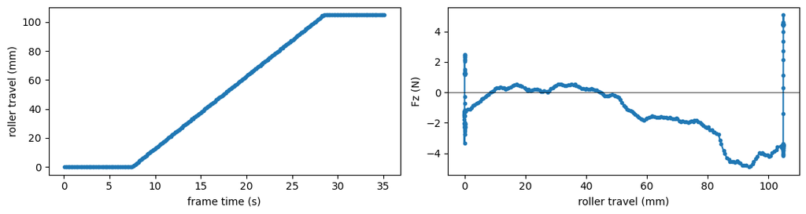

```python
ee = trial["ee_poses"]
t_ee  = np.array([e["t"] for e in ee])
y_ee  = np.array([e["position"][1] for e in ee])
fz_ee = np.array([e["force_xyz"][2] for e in ee])
y_start = trial["compressed_start_position"][1]

travel_mm = (np.interp(t_rf, t_ee, y_ee) - y_start) * 1000.0
force_z   = np.interp(t_rf, t_ee, fz_ee)

# Frames captured while the roller is actually traversing the sensor.
in_slide = (travel_mm > 1.0) & (travel_mm < roll_mm - 1.0)
print(f"in-slide frames : {in_slide.sum()}/{N}  "
      f"(travel {travel_mm[in_slide].min():.1f}..{travel_mm[in_slide].max():.1f} mm)")

fig, ax = plt.subplots(1, 2, figsize=(11, 3))
ax[0].plot(t_rf, travel_mm, ".-"); ax[0].set(xlabel="frame time (s)", ylabel="roller travel (mm)")
ax[1].plot(travel_mm, force_z, ".-"); ax[1].set(xlabel="roller travel (mm)", ylabel="Fz (N)")
ax[1].axhline(0, color="k", lw=0.5); plt.tight_layout()
```

### Reference Signals (no-contact baseline)

Mean of the `static_rf` frames per channel. Subtracting this isolates the change caused by the rolling contact (the analog of the static depth-0/force-0 reference).

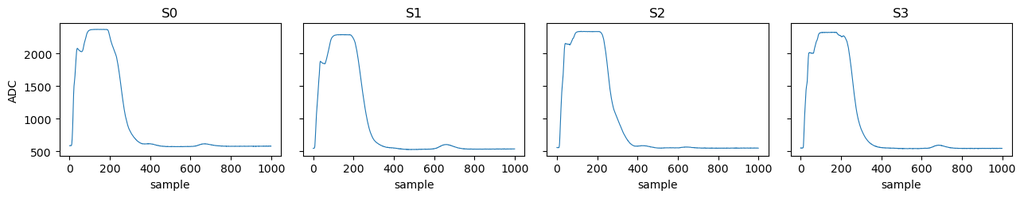

```python
reference = ref_raw.mean(axis=0)            # (4, 1000)

fig, ax = plt.subplots(1, 4, figsize=(13, 2.6), sharey=True)
for c in range(4):
    ax[c].plot(reference[c], lw=0.8)
    ax[c].set_title(CHANNELS[c]); ax[c].set_xlabel("sample")
ax[0].set_ylabel("ADC")
plt.tight_layout()
```

### Pre-Processing

Mirrors the static pipeline:

1. **Alignment (jitter removal)** — align every frame on the first crossing of `A_CROSS` (the transmit pulse) so pulse-to-pulse timing jitter is removed.
2. **Baseline subtraction** — subtract the no-contact reference, and mark any clipped (saturated) samples as `NaN` so the peak-finder can recover them.

```python
A_CROSS  = 1500     # first-crossing trigger level (transmit pulse ~2300 ADC)
L_SIGNAL = 900      # length kept after the crossing
A_CLIP   = 4000     # saturation level; samples >= this are masked to NaN

def align(rf):
    """First-crossing alignment, per frame per channel -> (n,4,L_SIGNAL)."""
    n, ch, _ = rf.shape
    out = np.empty((n, ch, L_SIGNAL), dtype=float)
    for i in range(n):
        for c in range(ch):
            idx = int(np.argmax(rf[i, c] > A_CROSS))
            idx = min(idx, rf.shape[2] - L_SIGNAL)
            out[i, c] = rf[i, c, idx:idx + L_SIGNAL]
    return out

rf_al  = align(rf_raw)
ref_al = align(ref_raw).mean(axis=0)        # aligned reference (4, L_SIGNAL)

# Baseline subtraction (+ NaN out saturated samples)
processed = rf_al - ref_al[None]            # (N, 4, L_SIGNAL)
processed[rf_al >= A_CLIP] = np.nan
print("processed shape:", processed.shape)
```

```
processed shape: (315, 4, 900)
```

### Waterfall: contact echo as the roller moves

Stacking the **jitter-aligned, baseline-subtracted** envelope of one channel against roller travel shows where the contact echo sits and how it shifts / strengthens during the roll. Restricted to the **in-slide** frames and using the same aligned frames as the peak-finding pipeline, so the two are consistent. This is the rolling counterpart of plotting the individual static signals.

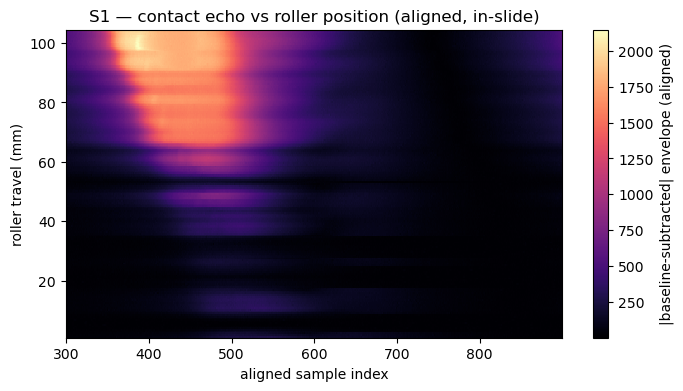

```python
W_START, W_END = 300, L_SIGNAL          # echo window in *aligned* sample coords
FOCUS = 1                               # waveguide to visualise

seg = np.nan_to_num(processed[in_slide, FOCUS, W_START:W_END])  # aligned + baseline-subtracted
env = np.abs(hilbert(seg, axis=1))
y = travel_mm[in_slide]
order = np.argsort(y)
plt.figure(figsize=(8, 4))
plt.pcolormesh(np.arange(W_START, W_END), y[order], env[order], shading="auto", cmap="magma")
plt.colorbar(label="|baseline-subtracted| envelope (aligned)")
plt.xlabel("aligned sample index"); plt.ylabel("roller travel (mm)")
plt.title(f"{CHANNELS[FOCUS]} — contact echo vs roller position (aligned, in-slide)")
```

### Library of Peak-Finding Functions

Identical to the static notebook so results are directly comparable — see its doc strings for details. `_v4`/`_v5` expect a signal already trimmed with the clipped plateau replaced by a contiguous `NaN` run (which is what our pre-processing produces). **Account for clipped signals.**

```python
def peak_finding_v1(signal, a_clip=1750, fit_threshold=0.70, poly_degree=4,
                    start=550, end=900, median_filt=11, method="poly"):
    """argmax for unclipped pulses; polynomial cap-fit recovery for clipped ones."""
    signal_clip = signal.copy()[start:end]
    if median_filt is not None:
        signal_clip = median_filter(signal_clip, size=median_filt)
    max_val = signal_clip.max()
    if max_val >= a_clip:
        fit_lower_bound = a_clip * fit_threshold
        valid = np.where((signal_clip >= fit_lower_bound) & (signal_clip < a_clip))[0]
        poly_amp = poly_tof = None
        if len(valid) >= poly_degree + 1:
            coeffs = np.polyfit(np.arange(len(signal_clip))[valid], signal_clip[valid], poly_degree)
            xs = np.linspace(valid[0], valid[-1], 500); ys = np.poly1d(coeffs)(xs)
            poly_amp = ys.max(); poly_tof = xs[ys.argmax()]
        if method == "poly":
            tof = poly_tof
        elif method == "center":
            ci = np.where(signal_clip >= a_clip)[0]
            tof = (ci[0] + ci[-1]) / 2.0 if len(ci) else None
        else:
            raise ValueError(method)
        if tof is not None and poly_amp is not None:
            return tof + start, poly_amp
    return signal_clip.argmax() + start, max_val


def peak_finding_v4(signal, fit_threshold=0.70, poly_degree=4, median_filt=11, method="poly"):
    """v1 for pre-trimmed signals whose clipped plateau is already a NaN run."""
    s = np.asarray(signal, dtype=float).copy(); nan = np.isnan(s)
    if median_filt is not None:
        if nan.any():
            cap = np.nanmax(s); filled = np.where(nan, cap, s)
            s = median_filter(filled, size=median_filt); s[nan] = np.nan
        else:
            s = median_filter(s, size=median_filt)
    if nan.any():
        cap = np.nanmax(s); fit_lower = cap * fit_threshold
        valid = np.where((~np.isnan(s)) & (s >= fit_lower))[0]
        poly_amp = poly_tof = None
        if len(valid) >= poly_degree + 1:
            coeffs = np.polyfit(valid, s[valid], poly_degree)
            xs = np.linspace(valid[0], valid[-1], 500); ys = np.poly1d(coeffs)(xs)
            poly_amp = ys.max(); poly_tof = xs[ys.argmax()]
        if method == "poly":
            tof = poly_tof
        elif method == "center":
            ni = np.where(nan)[0]; tof = (ni[0] + ni[-1]) / 2.0
        else:
            raise ValueError(method)
        if tof is not None and poly_amp is not None:
            return tof, poly_amp
    return int(np.nanargmax(s)), float(np.nanmax(s))


def peak_finding_v5(signal, fit_threshold=0.70, poly_degree=4, median_filt=11,
                    method="poly", centroid_threshold=0.9):
    """Like v4 but unclipped ToF = amplitude-weighted centroid above threshold;
    `method='centroid'` also fills the clipped region from the polynomial fit."""
    s = np.asarray(signal, dtype=float).copy(); nan = np.isnan(s)
    if median_filt is not None:
        s = generic_filter(signal, np.nanmedian, size=median_filt, mode="reflect")
    if nan.any():
        cap = np.nanmax(s); fit_lower = cap * fit_threshold
        valid = np.where((~np.isnan(s)) & (s >= fit_lower))[0]
        poly_amp = poly_tof = None; poly_func = None
        if len(valid) >= poly_degree + 1:
            coeffs = np.polyfit(valid, s[valid], poly_degree); poly_func = np.poly1d(coeffs)
            xs = np.linspace(valid[0], valid[-1], 500); ys = poly_func(xs)
            poly_amp = ys.max(); poly_tof = xs[ys.argmax()]
        if method == "poly":
            tof = poly_tof
        elif method == "center":
            ni = np.where(nan)[0]; tof = (ni[0] + ni[-1]) / 2.0
        elif method == "centroid":
            tof = None
            if poly_amp is not None:
                x = np.arange(len(s)); recon = s.copy()
                fill = nan & (x >= valid[0]) & (x <= valid[-1]); recon[fill] = poly_func(x[fill])
                mask = (~np.isnan(recon)) & (recon >= centroid_threshold * poly_amp)
                denom = np.sum(recon[mask])
                if denom != 0 and np.isfinite(denom):
                    tof = np.sum(x[mask] * recon[mask]) / denom
        else:
            raise ValueError(method)
        if tof is not None and poly_amp is not None:
            return tof, poly_amp
    max_val = np.nanmax(s); x = np.arange(len(s))
    mask = (~np.isnan(s)) & (s >= centroid_threshold * max_val)
    return np.sum(x[mask] * s[mask]) / np.sum(s[mask]), max_val
```

### Perform Peak-Finding

We run the peak-finder on the **absolute** baseline-subtracted signal, restricted to the echo window, for every frame and every waveguide. `(tof, amp)` are stored in arrays shaped `(N, 4)`.

```python
# Echo window expressed in the *aligned* frame (after the first-crossing shift the
# transmit pulse sits near index 0, so search a bit later).
PK_START, PK_END = 300, L_SIGNAL
A_MIN = 15            # minimum amplitude to count a frame as a real contact

tof = np.full((N, 4), np.nan)
amp = np.full((N, 4), np.nan)
for i in range(N):
    for c in range(4):
        seg = np.abs(processed[i, c, PK_START:PK_END])
        if np.all(np.isnan(seg)):
            continue
        p, a = peak_finding_v5(seg, median_filt=7, method="centroid", centroid_threshold=0.5)
        tof[i, c] = p + PK_START
        amp[i, c] = a

detected = (amp > A_MIN) & in_slide[:, None]
print("detected contact frames per channel:", detected.sum(axis=0).tolist())
```

```
detected contact frames per channel: [184, 182, 181, 183]
```

### Plot Results — ToF / peak-index vs roller travel

The rolling analog of "peak index vs true distance". Each point is one frame; colour is the contact force. A clean monotonic trend means the ToF tracks the moving contact position.

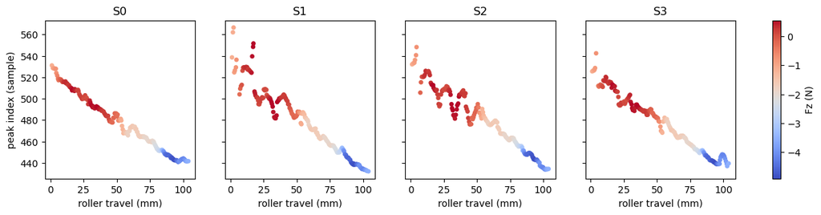

```python
fig, ax = plt.subplots(1, 4, figsize=(14, 3), sharex=True, sharey=True)
for c in range(4):
    m = detected[:, c]
    sc = ax[c].scatter(travel_mm[m], tof[m, c], c=force_z[m], s=14, cmap="coolwarm")
    ax[c].set_title(CHANNELS[c]); ax[c].set_xlabel("roller travel (mm)")
ax[0].set_ylabel("peak index (sample)")
fig.colorbar(sc, ax=ax, label="Fz (N)", fraction=0.02)
```

### Amplitude Trends

Amplitude vs roller travel and vs contact force — how strongly each waveguide responds as the contact moves along the sensor.

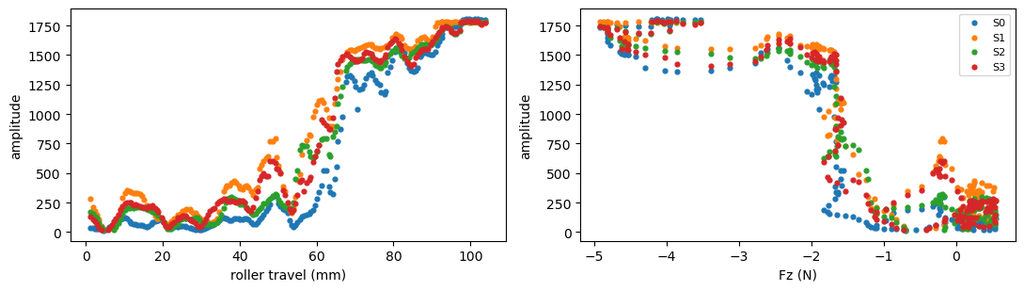

```python
fig, ax = plt.subplots(1, 2, figsize=(11, 3.2))
for c in range(4):
    m = detected[:, c]
    ax[0].scatter(travel_mm[m], amp[m, c], s=12, label=CHANNELS[c])
    ax[1].scatter(force_z[m], amp[m, c], s=12, label=CHANNELS[c])
ax[0].set(xlabel="roller travel (mm)", ylabel="amplitude")
ax[1].set(xlabel="Fz (N)", ylabel="amplitude"); ax[1].legend(fontsize=8)
plt.tight_layout()
```

### Error Statistics

Fit peak-index -> roller travel (per channel) and report RMSE / MAE / R², exactly as the static notebook reports the location-calibration fit.

```python
for c in range(4):
    m = detected[:, c]
    if m.sum() < 3:
        print(f"{CHANNELS[c]}: too few detected frames ({m.sum()})"); continue
    x, y = tof[m, c], travel_mm[m]
    slope, intercept = np.polyfit(x, y, 1)
    pred = slope * x + intercept
    rmse = np.sqrt(np.mean((y - pred) ** 2))
    mae = np.mean(np.abs(y - pred))
    r2 = 1 - np.sum((y - pred) ** 2) / np.sum((y - y.mean()) ** 2)
    print(f"{CHANNELS[c]}: travel = {slope:.3f}*peak + {intercept:.1f}   "
          f"RMSE={rmse:.2f} mm  MAE={mae:.2f} mm  R2={r2:.3f}  (n={m.sum()})")
```

```
S0: travel = -1.161*peak + 608.0   RMSE=3.72 mm  MAE=2.73 mm  R2=0.984  (n=184)
S1: travel = -0.926*peak + 498.4   RMSE=7.76 mm  MAE=5.13 mm  R2=0.930  (n=182)
S2: travel = -1.030*peak + 549.2   RMSE=6.67 mm  MAE=4.68 mm  R2=0.948  (n=181)
S3: travel = -1.134*peak + 594.9   RMSE=4.99 mm  MAE=3.60 mm  R2=0.971  (n=183)
```

### Localization Quality — predicted vs true roller position

Calibrate `peak index -> travel` per waveguide (linear fit on the detected frames), then use it to **predict the roller position** and compare against the known travel. Points on the dashed `y = x` line are perfect localization; the residual panel shows the error along the roll. The **fused** estimate averages the per-waveguide predictions for a single position readout.

```
Per-channel localization error (RMSE / MAE / max|err|, mm):
  S0:  3.72 /  2.73 / 10.13   (n=184)
  S1:  7.76 /  5.13 / 29.86   (n=182)
  S2:  6.67 /  4.68 / 21.20   (n=181)
  S3:  4.99 /  3.60 / 24.43   (n=183)
  FUSED (4-wg mean):  4.18 /  2.96 / 13.12   (n=185)
```

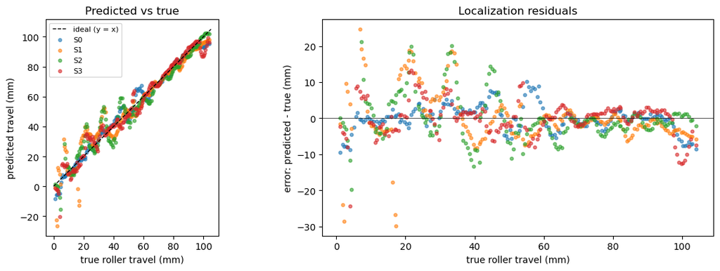

```python
# Per-channel calibration peak -> travel, then predict and compare to truth.
fig, ax = plt.subplots(1, 2, figsize=(12, 4.2))
lim = [0, roll_mm]
ax[0].plot(lim, lim, "k--", lw=1, label="ideal (y = x)")

pred_all = np.full((N, 4), np.nan)
for c in range(4):
    m = detected[:, c]
    if m.sum() < 3:
        continue
    slope, intercept = np.polyfit(tof[m, c], travel_mm[m], 1)
    pred = slope * tof[:, c] + intercept            # predicted travel, all frames
    pred_all[:, c] = np.where(detected[:, c], pred, np.nan)
    ax[0].scatter(travel_mm[m], pred[m], s=12, alpha=0.6, label=CHANNELS[c])
    ax[1].scatter(travel_mm[m], pred[m] - travel_mm[m], s=12, alpha=0.6, label=CHANNELS[c])

ax[0].set(xlabel="true roller travel (mm)", ylabel="predicted travel (mm)",
          title="Predicted vs true"); ax[0].legend(fontsize=8); ax[0].set_aspect("equal", "box")
ax[1].axhline(0, color="k", lw=0.5)
ax[1].set(xlabel="true roller travel (mm)", ylabel="error: predicted - true (mm)",
          title="Localization residuals")
plt.tight_layout()

# Fused (multi-waveguide) position estimate = mean of available per-channel preds.
fused = np.nanmean(pred_all, axis=1)
mf = in_slide & np.isfinite(fused)
err = fused[mf] - travel_mm[mf]
print(f"Per-channel localization error (RMSE / MAE / max|err|, mm):")
for c in range(4):
    m = detected[:, c]
    if m.sum() < 3:
        print(f"  {CHANNELS[c]}: n/a"); continue
    e = pred_all[m, c] - travel_mm[m]
    print(f"  {CHANNELS[c]}: {np.sqrt(np.mean(e**2)):5.2f} / {np.mean(np.abs(e)):5.2f} / {np.max(np.abs(e)):5.2f}   (n={m.sum()})")
print(f"  FUSED (4-wg mean): {np.sqrt(np.mean(err**2)):5.2f} / {np.mean(np.abs(err)):5.2f} / {np.max(np.abs(err)):5.2f}   (n={mf.sum()})")
```

### Compare Across Speeds / Repeats

Overlay the amplitude-vs-travel curve for every pickle in the same trial folder to see how rolling speed affects the response.

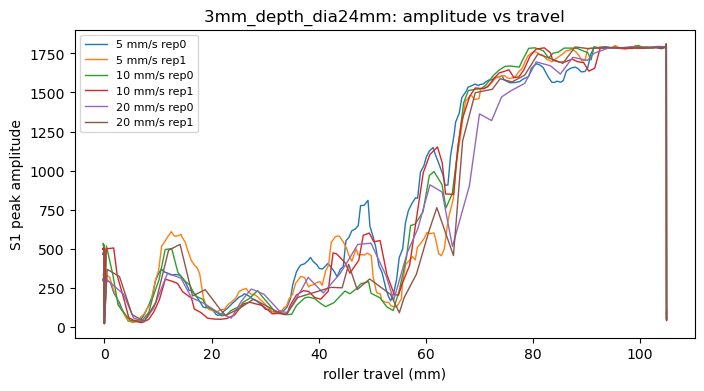

```python
trial_dir = TRIAL_FILE.parent
plt.figure(figsize=(8, 4))
for pkl in sorted(trial_dir.glob("rolling_speed_*_rep_*.pkl")):
    dt = load_trial(pkl)["trial"]
    r, tr_ = frames_to_array(dt["frames"])
    rr, _ = frames_to_array(dt["static_rf"]["frames"])
    if r.size == 0 or rr.size == 0:
        continue
    ref_ = align(rr).mean(0); pr = align(r) - ref_[None]
    ee_ = dt["ee_poses"]; te_ = np.array([e["t"] for e in ee_])
    ye_ = np.array([e["position"][1] for e in ee_])
    trav = (np.interp(tr_, te_, ye_) - dt["compressed_start_position"][1]) * 1000.0
    # FOCUS-channel peak amplitude per frame
    a = np.array([np.nanmax(np.abs(pr[i, FOCUS, PK_START:PK_END])) for i in range(pr.shape[0])])
    o = np.argsort(trav)
    plt.plot(trav[o], a[o], lw=1, label=f"{dt['speed_m_s']*1000:.0f} mm/s rep{dt.get('repeat_idx',0)}")
plt.xlabel("roller travel (mm)"); plt.ylabel(f"{CHANNELS[FOCUS]} peak amplitude")
plt.legend(fontsize=8); plt.title(f"{trial_dir.name}: amplitude vs travel")
```

### Sweep — localization across depth / diameter / speed

Run the full localization pipeline on **every labelled trial** (`Nmm_depth_diaMmm` folders: compression depth x roller diameter x speed x repeat) and summarise the fused 4-waveguide RMSE. Tells us which conditions give the best contact tracking. Reuses the same `align()` / `peak_finding_v5` / window settings defined above, so every trial is processed identically to the detailed example.

*(The `*_new` re-run folders are excluded. This cell processes ~48 trials and is the slow one — a few minutes.)*

```
analyzed 48 trials

fused localization RMSE (mm), mean over repeats:
depth | 10mm  24mm  roller   x speed
  1mm  dia10mm :  9.27   7.05   7.67   (speeds [5.0, 10.0, 20.0] mm/s)
  1mm  dia24mm : 14.15  13.40   9.64   (speeds [5.0, 10.0, 20.0] mm/s)
  2mm  dia10mm :  7.82   9.17   8.87   (speeds [5.0, 10.0, 20.0] mm/s)
  2mm  dia24mm :  8.18   8.37   9.18   (speeds [5.0, 10.0, 20.0] mm/s)
  3mm  dia10mm :  5.61   5.74   5.56   (speeds [5.0, 10.0, 20.0] mm/s)
  3mm  dia24mm :  4.25   4.30   4.43   (speeds [5.0, 10.0, 20.0] mm/s)
  4mm  dia10mm :  3.73   3.39   3.36   (speeds [5.0, 10.0, 20.0] mm/s)
  4mm  dia24mm :  5.55   6.03   5.96   (speeds [5.0, 10.0, 20.0] mm/s)
```

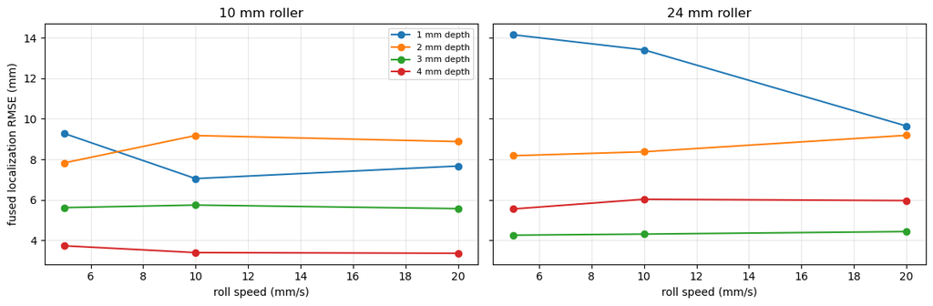

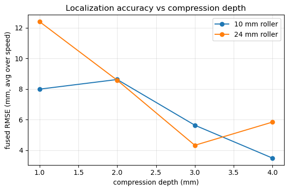

```python
import re, collections, warnings
warnings.filterwarnings("ignore", message="Mean of empty slice")

def analyze_file(path):
    """Full pipeline -> fused localization RMSE/MAE for one trial pickle."""
    d = load_trial(path)["trial"]
    rf, t = frames_to_array(d["frames"])
    rr, _ = frames_to_array(d["static_rf"]["frames"])
    if rf.size == 0 or rr.size == 0:
        return None
    rf_al = align(rf); ref_al = align(rr).mean(0)
    proc = rf_al - ref_al[None]; proc[rf_al >= A_CLIP] = np.nan
    n = rf.shape[0]; roll = d["roll_distance_m"] * 1000
    ee = d["ee_poses"]; te = np.array([e["t"] for e in ee])
    ye = np.array([e["position"][1] for e in ee])
    travel = (np.interp(t, te, ye) - d["compressed_start_position"][1]) * 1000
    in_slide = (travel > 1) & (travel < roll - 1)
    tof = np.full((n, 4), np.nan)
    amp = np.full((n, 4), np.nan)
    for i in range(n):
        for c in range(4):
            seg = np.abs(proc[i, c, PK_START:PK_END])
            if np.all(np.isnan(seg)):
                continue
            p, a = peak_finding_v5(seg, median_filt=7, method="centroid", centroid_threshold=0.5)
            tof[i, c] = p + PK_START; amp[i, c] = a
    det = (amp > A_MIN) & in_slide[:, None]
    pred = np.full((n, 4), np.nan); per = [np.nan] * 4
    for c in range(4):
        m = det[:, c]
        if m.sum() < 3:
            continue
        sl, ic = np.polyfit(tof[m, c], travel[m], 1)
        pred[:, c] = np.where(det[:, c], sl * tof[:, c] + ic, np.nan)
        e = pred[m, c] - travel[m]; per[c] = np.sqrt(np.mean(e ** 2))
    fused = np.nanmean(pred, axis=1); mf = in_slide & np.isfinite(fused)
    err = fused[mf] - travel[mf]
    return {"fused_rmse": float(np.sqrt(np.mean(err ** 2))) if mf.sum() else np.nan,
            "fused_mae":  float(np.mean(np.abs(err))) if mf.sum() else np.nan,
            "best_rmse":  float(np.nanmin(per)) if np.any(np.isfinite(per)) else np.nan,
            "n": int(mf.sum())}

rows = []
for folder in sorted(RESULTS_DIR.glob("*mm_depth_dia*mm")):
    m = re.match(r"(\d+)mm_depth_dia(\d+)mm$", folder.name)
    if not m:
        continue
    depth, dia = int(m.group(1)), int(m.group(2))
    for pkl in sorted(folder.glob("rolling_speed_*_rep_*.pkl")):
        sm = re.search(r"speed_([0-9.]+)_mm_s_rep_(\d+)", pkl.name)
        r = analyze_file(pkl)
        if r:
            rows.append(dict(depth=depth, dia=dia, speed=float(sm.group(1)), rep=int(sm.group(2)), **r))
print(f"analyzed {len(rows)} trials")

# Mean fused RMSE over repeats, keyed by (depth, dia, speed)
agg = collections.defaultdict(list)
for r in rows:
    agg[(r["depth"], r["dia"], r["speed"])].append(r["fused_rmse"])
depths = sorted({r["depth"] for r in rows})
dias   = sorted({r["dia"]   for r in rows})
speeds = sorted({r["speed"] for r in rows})

print("\nfused localization RMSE (mm), mean over repeats:")
print("depth |", "  ".join(f"{d}mm" for d in dias), " roller   x speed")
for depth in depths:
    for dia in dias:
        line = "  ".join(f"{np.mean(agg[(depth, dia, s)]):5.2f}" for s in speeds)
        print(f"  {depth}mm  dia{dia:2d}mm : {line}   (speeds {speeds} mm/s)")

# Plot 1: RMSE vs speed, one line per depth, one panel per diameter
fig, ax = plt.subplots(1, len(dias), figsize=(6 * len(dias), 4), sharey=True, squeeze=False)
for j, dia in enumerate(dias):
    for depth in depths:
        ax[0, j].plot(speeds, [np.mean(agg[(depth, dia, s)]) for s in speeds], "o-", label=f"{depth} mm depth")
    ax[0, j].set(title=f"{dia} mm roller", xlabel="roll speed (mm/s)"); ax[0, j].grid(alpha=0.3)
ax[0, 0].set_ylabel("fused localization RMSE (mm)"); ax[0, 0].legend(fontsize=8)
plt.tight_layout()

# Plot 2: RMSE vs depth (averaged over speed), one line per diameter
fig2, ax2 = plt.subplots(figsize=(6, 4))
for dia in dias:
    ax2.plot(depths, [np.mean([np.mean(agg[(depth, dia, s)]) for s in speeds]) for depth in depths],
             "o-", label=f"{dia} mm roller")
ax2.set(xlabel="compression depth (mm)", ylabel="fused RMSE (mm, avg over speed)",
        title="Localization accuracy vs compression depth"); ax2.legend(); ax2.grid(alpha=0.3)
plt.tight_layout()
```

### Repeatability — original vs re-run (`_new`)

```
analyzed 24 re-run trials

depth  dia  speed |  original   re-run    |diff|
  1mm  10mm     5 |    9.27    14.92     5.65
  1mm  10mm    10 |    7.05    21.35    14.30
  1mm  10mm    20 |    7.67    20.02    12.35
  2mm  10mm     5 |    7.82     9.34     1.51
  2mm  10mm    10 |    9.17    15.49     6.32
  2mm  10mm    20 |    8.87    17.51     8.64
  3mm  10mm     5 |    5.61     4.98     0.64
  3mm  10mm    10 |    5.74     5.21     0.52
  3mm  10mm    20 |    5.56     7.17     1.61
  4mm  10mm     5 |    3.73     4.02     0.29
  4mm  10mm    10 |    3.39     3.83     0.44
  4mm  10mm    20 |    3.36     6.20     2.85

mean |original - re-run| RMSE = 4.59 mm   (max 14.30 mm, n=12)
```

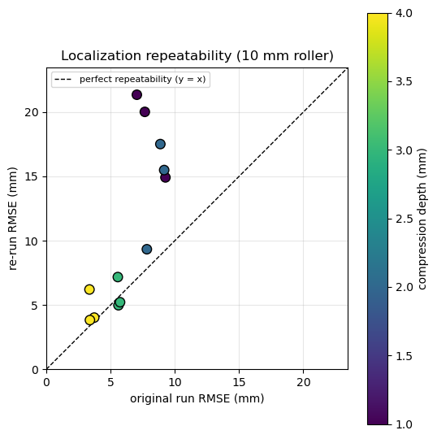

```python
# Analyse the _new re-runs (reuses analyze_file / rows from the sweep above).
new_rows = []
for folder in sorted(RESULTS_DIR.glob("*mm_depth_dia*mm_new")):
    m = re.match(r"(\d+)mm_depth_dia(\d+)mm_new$", folder.name)
    if not m:
        continue
    depth, dia = int(m.group(1)), int(m.group(2))
    for pkl in sorted(folder.glob("rolling_speed_*_rep_*.pkl")):
        sm = re.search(r"speed_([0-9.]+)_mm_s_rep_(\d+)", pkl.name)
        r = analyze_file(pkl)
        if r:
            new_rows.append(dict(depth=depth, dia=dia, speed=float(sm.group(1)), rep=int(sm.group(2)), **r))
print(f"analyzed {len(new_rows)} re-run trials")

# Mean fused RMSE over reps for originals (rows) and re-runs (new_rows).
def mean_rmse(table):
    g = collections.defaultdict(list)
    for r in table:
        g[(r["depth"], r["dia"], r["speed"])].append(r["fused_rmse"])
    return {k: float(np.mean(v)) for k, v in g.items()}

orig_m, new_m = mean_rmse(rows), mean_rmse(new_rows)
keys = sorted(new_m.keys() & orig_m.keys())

print("\ndepth  dia  speed |  original   re-run    |diff|")
diffs = []
for k in keys:
    o, nw = orig_m[k], new_m[k]
    diffs.append(abs(o - nw))
    print(f"  {k[0]}mm  {k[1]}mm  {k[2]:4.0f} | {o:7.2f}  {nw:7.2f}   {abs(o-nw):6.2f}")
diffs = np.array(diffs)
print(f"\nmean |original - re-run| RMSE = {diffs.mean():.2f} mm   (max {diffs.max():.2f} mm, n={len(keys)})")

# Plot: original vs re-run RMSE (each matched condition), with y = x.
o = np.array([orig_m[k] for k in keys]); nw = np.array([new_m[k] for k in keys])
depth_of = np.array([k[0] for k in keys])
fig, ax = plt.subplots(figsize=(5.5, 5.5))
lim = [0, max(o.max(), nw.max()) * 1.1]
ax.plot(lim, lim, "k--", lw=1, label="perfect repeatability (y = x)")
sc = ax.scatter(o, nw, c=depth_of, s=70, cmap="viridis", edgecolor="k", zorder=3)
plt.colorbar(sc, label="compression depth (mm)")
ax.set(xlabel="original run RMSE (mm)", ylabel="re-run RMSE (mm)",
       title="Localization repeatability (10 mm roller)", xlim=lim, ylim=lim)
ax.set_aspect("equal", "box"); ax.legend(fontsize=8); ax.grid(alpha=0.3)
plt.tight_layout()
```